# ida_hmw_1.2.3

Mehdi

19 octobre 2018

## Goal

Choosing a subset of 4 or 5 quantitative variables and explore linear relationships.

```r
library(moments)
library(corrplot)
cars = read.delim("/home/mehdi/Bureau/ida_hmw_1.2/cars.txt", sep = "", dec = ".")
```

For this part, we decided to choose 5 quantitative variables : mpg, displacement, horsepower, weight and acceleration We created a new data set with only these 5 quantitative variables : carsquant

```r
carsquant=as.data.frame(cars[,3:6], title=TRUE)
carsquant$mpg <- cars$mpg
```

### Covariance and Correlation matrix

```r
cov(carsquant)
```

```
##              displacement horsepower     weight acceleration          mpg
## displacement   14059.2749  4934.5437 104179.994  -255.431803  -652.531463
## horsepower      4934.5437  2117.8963  37334.261  -108.582406  -232.848021
## weight        104179.9943 37334.2612 926330.561 -1519.561626 -5490.923624
## acceleration    -255.4318  -108.5824  -1519.562    10.029351     9.505519
## mpg             -652.5315  -232.8480  -5490.924     9.505519    39.971707
```

```r
r=cor(carsquant)
r
```

```
##              displacement horsepower     weight acceleration        mpg
## displacement    1.0000000  0.9043014  0.9128930   -0.6802321 -0.8704496
## horsepower      0.9043014  1.0000000  0.8428926   -0.7450248 -0.8002835
## weight          0.9128930  0.8428926  1.0000000   -0.4985387 -0.9023729
## acceleration   -0.6802321 -0.7450248 -0.4985387    1.0000000  0.4747480
## mpg            -0.8704496 -0.8002835 -0.9023729    0.4747480  1.0000000
```

We just displayed below the R-matrix. We can visualize it with a plot showing the correlation between the variables in a more intuitive way :

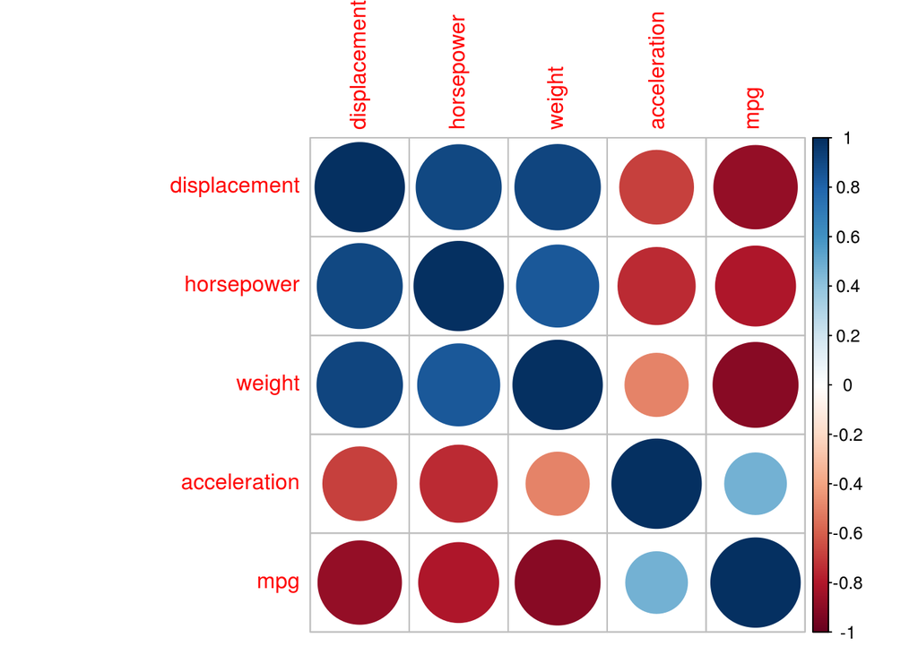

```r
corrplot(r, method = "circle")
```

Which variables are correlated the most ?

```r
diag(r)=0
which(r==max(abs(r)), arr.ind=TRUE)
```

```
##              row col
## weight         3   1
## displacement   1   3
```

The more correlated variables are weight and displacement which is logical because physically, displacement is strongly related to the car’s weight. Indeed, the correlation between these two variables is : 0.9128930 which is very high. We have a very strong linear relationship which implies that variables are measuring almost the same thing. However, in absolute value, the correlation between all these variables apart between acceleration and weight (0.4985387) and between acceleration and mpg (0.4747480) are high. We have a strong relationship implying that we can be confident that these two variables are connected in some way.

### Partial correlations

Let’s explore the relationship between our 5 variables through partial correlations :

```r
library(ppcor)
pcor(carsquant)
```

```
## $estimate
##              displacement  horsepower     weight acceleration         mpg
## displacement    1.0000000  0.27382566  0.5160035   -0.3932440 -0.25186293
## horsepower      0.2738257  1.00000000  0.2526219   -0.5084560 -0.09316666
## weight          0.5160035  0.25262188  1.0000000    0.3735432 -0.42654320
## acceleration   -0.3932440 -0.50845604  0.3735432    1.0000000 -0.16517990
## mpg            -0.2518629 -0.09316666 -0.4265432   -0.1651799  1.00000000
##
## $p.value
##              displacement   horsepower       weight acceleration
## displacement 0.000000e+00 6.942485e-03 7.419376e-08 7.387916e-05
## horsepower   6.942485e-03 0.000000e+00 1.302182e-02 1.231097e-07
## weight       7.419376e-08 1.302182e-02 0.000000e+00 1.777786e-04
## acceleration 7.387916e-05 1.231097e-07 1.777786e-04 0.000000e+00
## mpg          1.330641e-02 3.666049e-01 1.468146e-05 1.077708e-01
##                       mpg
## displacement 1.330641e-02
## horsepower   3.666049e-01
## weight       1.468146e-05
## acceleration 1.077708e-01
## mpg          0.000000e+00
##
## $statistic
##              displacement horsepower    weight acceleration        mpg
## displacement     0.000000  2.7603403  5.840438    -4.146727 -2.5232438
## horsepower       2.760340  0.0000000  2.531365    -5.724925 -0.9072303
## weight           5.840438  2.5313646  0.000000     3.904253 -4.5722938
## acceleration    -4.146727 -5.7249254  3.904253     0.000000 -1.6237837
## mpg             -2.523244 -0.9072303 -4.572294    -1.623784  0.0000000
##
## $n
## [1] 99
##
## $gp
## [1] 3
##
## $method
## [1] "pearson"
```

```r
matrix.partial=pcor(carsquant)$estimate
```

Visualizing partial correlations

[figure not shown]

```r
library(corrgram)
library(corrplot)
corrgram(matrix.partial,
         lower.panel=panel.shade, upper.panel=panel.pie,
         diag.panel=panel.minmax, text.panel=panel.txt)
```

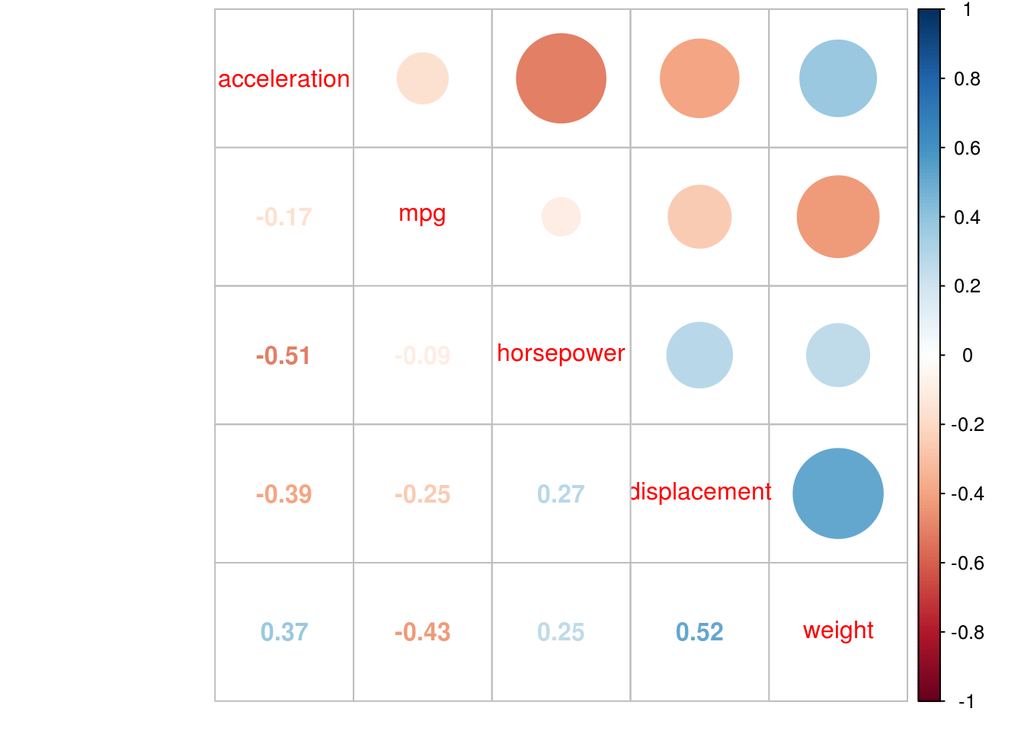

```r
corrplot.mixed(matrix.partial,order="AOE" )
```

Displaying the plots, we can see that partial correlations are closer to zero than ordinary correlations. In this case, this is suggesting that the relationship between the variables of interest could be explained by their common relationships to the explanatory variables upon which we are conditioning.

### Coefficient of determination

Define a function r2multv for squared multiple correlation coeficients

```r
r2multv<-function(x){
  r2s=1-1/(diag(solve(cov(x)))*diag(cov(x)))
  r2s
}
```

use it on data set “carsquant”

```r
r2multv(carsquant)
```

```
## displacement   horsepower       weight acceleration          mpg
##    0.9159490    0.8662318    0.8984768    0.6745925    0.8320842
```

The coefficient of determination of displacement, horsepower, weight and mpg “explained” by the correlation with the other variables are higher than 80%. This means that more than 80% of the variance of these variables is explained by the correlation. In other words an R2 of more than 0.80 means that 80 percent of the variance in these variables is predictable from the others. Concerning the coefficient of determination of acceleration, we have a 0.67, the data is some scattered.